# Project Bluecoats - Score Analysis And Visualization

# Read Me

**📌 Purpose**  
This notebook visualizes the performance progression of the Bluecoats Drum Corps across selected seasons, using caption-level DCI scoring data.  
The report aims to identify scoring patterns, highlight major performance shifts, and compare caption scores (**General Effect**, **Visual**, and **Music**) across the seasons. **📊 Data Source**

- "https://www.dci.org/scores/"
- Contains show-level scoring data for the Bluecoats, including overall scores and individual captions.

**Collection & Cleaning DCI.org**

- Initial Parsing
- Updating Latest Show Data
- Dataframes Displays

**Visualization**

- Preparation
- Total Score Graph
- Caption Score Graphs

**Future Outlook...**

Enjoy!

**Author**  
**Xi Cong**  
**July 2025**

```python
import requests
from bs4 import BeautifulSoup
import pandas as pd
from pprint import pprint
import importlib
```

# Colletion and Cleaning DCI.org

## Inital Parsing

Loops through all the shows documented on dci.org and writes the caption and sub caption scores into a csv file notated by date, location, corp name into a score_by_show&corp.csv

```python
import find_show_info as fds
importlib.reload(fds)
fds.scrape_dci_recaps_selenium()
fds.build_show_score_list()
fds.build_show_score_df()
```

## Updating Lastest Shows

Updates the lastest shows and write it to score_by_show.csv (name slightly different for differentiating purpose).

```python
import find_show_info as fds
importlib.reload(fds)
fds.build_lastest_show_score_df()
```

[output not shown]

[output cut: 244 more lines]

[output not shown]

## Dataframes

Raw html

```python
df_raw = pd.read_csv("all_shows_score_recap.csv")
pprint(df_raw.iloc[0, 0:5])
```

```
July 25, 2025                                                                                                                                                                July 25, 2025
Nashville, TN                                                                                                                                                               Birmingham, AL
General Effect|General Effect 1|T. Wemhoff|Rep|Perf|TOT|General Effect 2|M. Howard|Rep|Perf|TOT|TOT                                      General Effect|General Effect 1|A. Combites|Re...
Visual|Visual Proficiency|J. Orefice|Cont|Achv|TOT|Visual - Analysis|T. Ochran|Comp|Achv|TOT|Color Guard|M. McCourt|CONT|Achv|TOT|TOT    Visual|Visual Proficiency|J. Tate|Cont|Achv|TO...
Music|Music - Brass|P. McGarr|Cont|Achv|TOT|Music - Analysis|K. Turner|Cont|Achv|TOT|Music - Percussion|J. Brooks|Cont|Achv|TOT|TOT      Music|Music - Brass|N. Konouchi|Cont|Achv|TOT|...
Name: 0, dtype: object
```

All corps score at all shows

```python
df_all = pd.read_csv("score_by_show.csv")
display(df_all.head())
```

|  | Show Date | Show Location | Corp Name | General Effect - TOT | General Effect - TOT_rank | Visual - TOT | Visual - TOT_rank | Music - TOT | Music - TOT_rank | Sub Total | Sub Total_rank | Total | Total_rank |
| --- | --- | --- | --- | --- | --- | --- | --- | --- | --- | --- | --- | --- | --- |
| 0 | July 25, 2025 | Birmingham, AL | Blue Knights | 34.1 | 1 | 25.65 | 1 | 25.90 | 1 | 85.650 | 1 | 85.650 | 1 |
| 1 | July 25, 2025 | Birmingham, AL | Spirit of Atlanta | 32.9 | 2 | 24.75 | 2 | 25.20 | 2 | 82.850 | 2 | 82.850 | 2 |
| 2 | July 25, 2025 | Birmingham, AL | Crossmen | 31.7 | 3 | 24.15 | 3 | 24.40 | 3 | 80.250 | 3 | 80.250 | 3 |
| 3 | July 25, 2025 | Birmingham, AL | Genesis | 30.5 | 4 | 22.40 | 4 | 22.95 | 4 | 75.850 | 4 | 75.850 | 4 |
| 4 | July 25, 2025 | Birmingham, AL | Seattle Cascades | 29.4 | 5 | 22.15 | 5 | 22.40 | 5 | 73.950 | 5 | 73.950 | 5 |

All Bluecoats shows since 2013

```python
import find_show_info as fds
importlib.reload(fds)
fds.find_bluecoats()
```

|  | Show Date | Show Location | Corp Name | General Effect - TOT | General Effect - TOT_rank | Visual - TOT | Visual - TOT_rank | Music - TOT | Music - TOT_rank | Sub Total | Sub Total_rank | Total | Total_rank |
| --- | --- | --- | --- | --- | --- | --- | --- | --- | --- | --- | --- | --- | --- |
| 0 | July 20, 2025 | Bedford, TX | Bluecoats | 37.00 | 1 | 28.00 | 1 | 27.950 | 1 | 92.950 | 1 | 92.950 | 1 |
| 12 | July 19, 2025 | San Antonio, TX | Bluecoats | 37.35 | 1 | 27.80 | 1 | 27.675 | 3 | 92.825 | 2 | 92.825 | 2 |
| 31 | July 18, 2025 | Houston, TX | Bluecoats | 36.90 | 1 | 26.90 | 1 | 27.450 | 1 | 91.250 | 1 | 91.250 | 1 |
| 39 | July 17, 2025 | Denton, TX | Bluecoats | 36.40 | 1 | 26.85 | 1 | 27.050 | 2 | 90.300 | 1 | 90.300 | 1 |
| 66 | July 15, 2025 | Broken Arrow, OK | Bluecoats | 35.60 | 1 | 26.50 | 1 | 26.450 | 1 | 88.550 | 1 | 88.550 | 1 |

# Visualization

## Preparation

Bluecoats color from media pictures

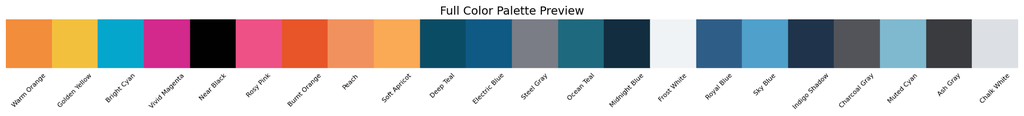

```python
import graph_scores as gs
importlib.reload(gs)
gs.show_color()
```

## Total Score Graphs

Bluecoat season score progression since 2013

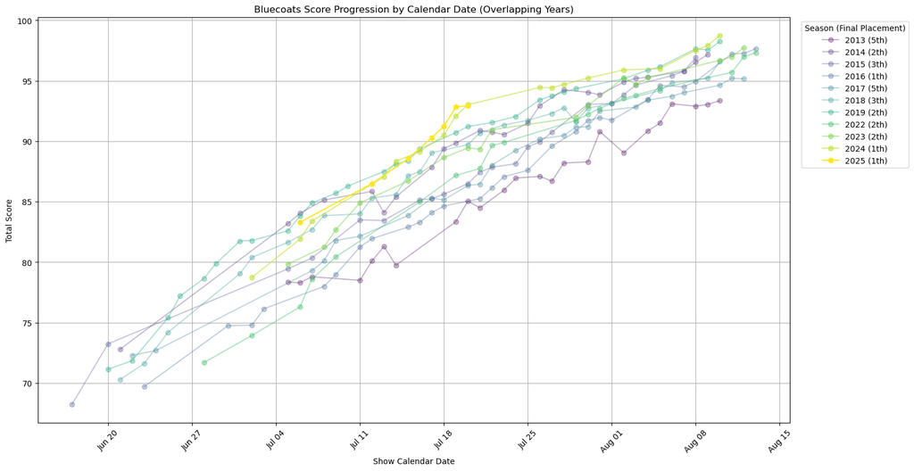

```python
import graph_scores as gs
importlib.reload(gs)
gs.bluecoats_season_trend()
```

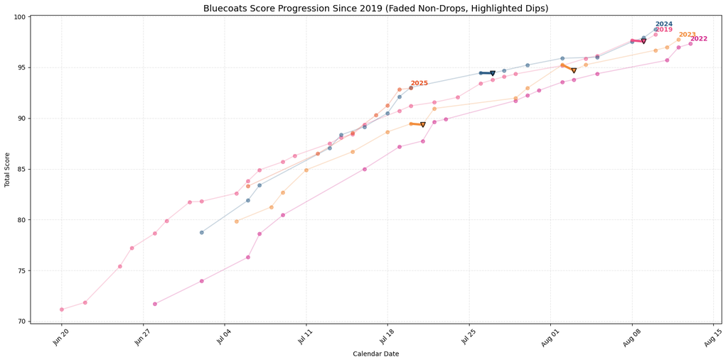

```python
import graph_scores as gs
importlib.reload(gs)
gs.bluecoats_season_trend_highlight_drops()
```

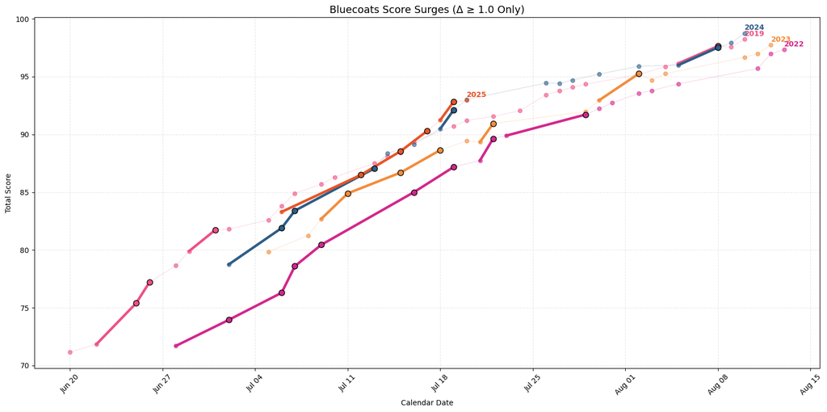

```python
import graph_scores as gs
importlib.reload(gs)
gs.bluecoats_season_trend_highlight_improvements()
```

Bluecoats season 2025 and past championship seasons.

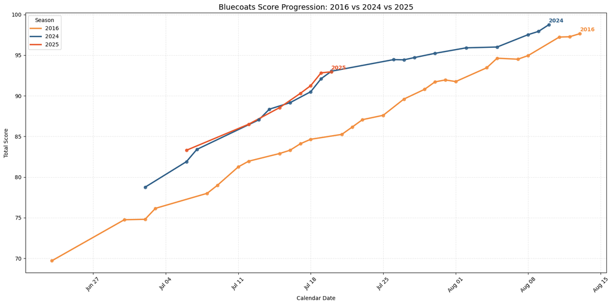

```python
import graph_scores as gs
importlib.reload(gs)
gs.bluecoats_champ_seasons_plot()
```

## Caption Score Graphs

Bluecoats caption score trend with year 2025, 2024, 2016, and average of 2019-2024

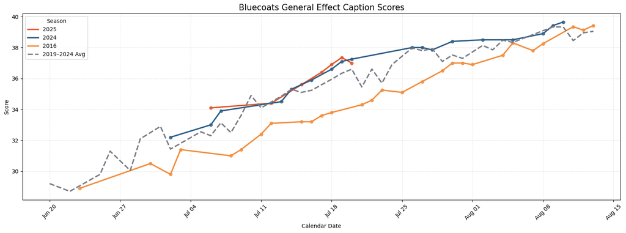

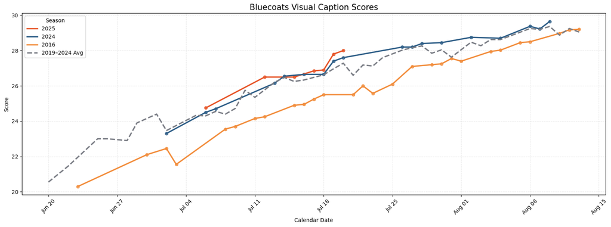

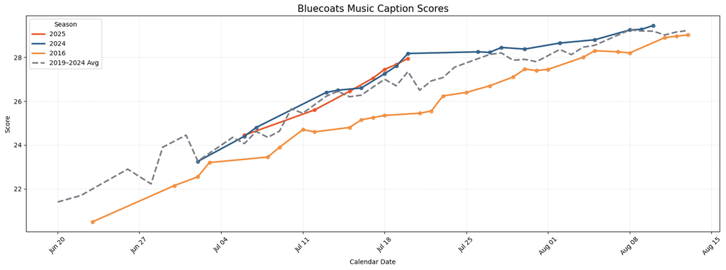

```python
import graph_scores as gs
importlib.reload(gs)
gs.bluecoats_caption_score_trend()
```

**Future Outlooks & Expansion Ideas**

- Analyze judging trends by **matching judge names to caption scores**, identifying potential judge-specific scoring patterns or biases.
- Determine Bluecoats' **caption rankings in finals** across multiple years to reveal recurring **strengths and weaknesses**.
- If data permits, visualize operational season metrics such as:
  - **Spring training workload**: total and average rehearsal hours per day.
  - **Tour logistics**: total/average miles traveled, bus time, and housing/floor time.
  - **Tour rehearsal intensity**: rehearsal hours per day while on tour.
- Compare **caption score trajectories** of Bluecoats with peer corps (e.g., BD, Crown) for performance trend benchmarking.
- Analyze **score volatility** over a season to identify stability vs. inconsistency.
- Examine the **relationship between performance order and score**, especially at regionals and finals.
- Track **individual caption improvements** post-major show rewrites (if timestamped notes are available).